# Modelling in R: A Chemostat

Thomas Petzoldt and Karline Soetaert

July-2021

[figure not shown]

- $N$ nutrient, e.g. phosphorus (mmol P / m3)
- $P$ phytoplankton, carbon (mmol C / m3)

## Introduction

The example shows a chemostat model (cf. Novick and Szilard 1950; Herbert, Elsworth, and Telling 1956) by example of heterotrophic or autotrophic organisms (bacteria, algae, $P$), where growth is limited by a single nutrient (e.g. phosphorus, $N$) via a Monod equation.

We use here a notation, compatible with the so-called NPZ and NPZD models where $N$ is a nutrient (nitrogen or phosphorus), $P$ is phytoplankton, $Z$ zooplankton and (optionally) $D$ is detritus. Please don’t get confused! Here **P** is phytoplankton and not phosphorus, while the symbol for the nutrient **N** does not necessarily mean that it is nitrogen.

The equations governing the dynamics of **P** and **N** are:
$$\frac{dN}{dt}=-r \cdot \frac{N}{k_n+N}\cdot P + d \cdot(N_0-N)$$
$$\frac{dP}{dt}=r \cdot \frac{N}{k_n+N}\cdot P + d \cdot(0-P)$$

where d is the dilution rate, and the nutrient and phytoplankton concentration in the inflowing water is $N_0$ and $0$ respectively.

## Implementation

The system of differential equations is solved numerically with solvers from package **deSolve** (Soetaert, Petzoldt, and Setzer 2010b), while equilibria at infinite time are estimated with package **rootSolve** (Soetaert 2009). The implementation follows the standard formulation of these packages, see package documentation of **deSolve** and **rootSolve**, and Soetaert, Petzoldt, and Setzer (2010b) or Soetaert, Petzoldt, and Setzer (2010a) for details. The code is written in the **R** programming language for statistical computing (R Core Team 2018).

### The code

```r
library("deSolve")
library("rootSolve")

chemostat <- function(time, y, parms) {
  with(as.list(c(y, parms)), {
    p_growth <- r_pgrow * N / (k_n + N) * P

    dN_dt   <- - c_pn * p_growth + d * (N0 - N)
    dP_dt   <-          p_growth + d * (0 - P)
    list(c(dN_dt, dP_dt), p_growth = p_growth)
   })
}
parms <- c(
  r_pgrow = 0.5,   # phytoplankton growth parameter (1/d)
  k_n     = 1.0,   # half saturation constant, P (mmol/m3)
  c_pn    = 1/106, # stoichiometric conversion from phosphorus P to phyto C (P:C ratio)
  d       = 0.1,   # dilution rate 1/d
  N0      = 5      # phosphorus in inflow (mmol/m3)
)
```

### Dynamic simulation

A dynamic simulation can then be performed by function `ode`, using the default algorithm `lsoda` with automatic integration step size. The result (`out`) is a matrix-like object of class `deSolve` that is supported by a generic (i.e. object oriented) plot function.

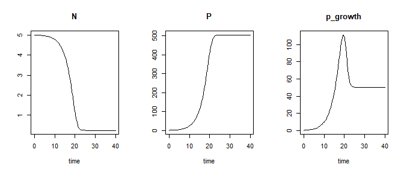

```r
times <- seq(from=0, to=40, length.out=100)  # simulation time (d)
y     <- c(N = 5, P = 1)                     # Nutrient (mmolP/m3) and Phytoplankton (mmolC/m3)
out   <- ode(y, times, chemostat, parms)
plot(out, mfrow=c(1, 3))
```

## Role of initial values

Let’s play around with the model and change some values. First let’s modify the initial values `y <- c(N = 5, P = 1)`:

- Set `N`utrient and/or `P`hytoplankton to smaller or bigger values.
- Set `P`hytoplankton to zero.
- If necessary, change the time period.

```r
library("deSolve")
library("rootSolve")

chemostat <- function(time, y, parms) {
  with(as.list(c(y, parms)), {
    p_growth <- r_pgrow * N / (k_n + N) * P

    dN_dt   <- - c_pn * p_growth + d * (N0 - N)
    dP_dt   <-          p_growth + d * (0 - P)
    list(c(dN_dt, dP_dt), p_growth = p_growth)
   })
}
parms <- c(
  r_pgrow = 0.5,   # phytoplankton growth parameter (1/d)
  k_n     = 1.0,   # half saturation constant, P (mmol/m3)
  c_pn    = 1/106, # stoichiometric conversion from phosphorus P to phyto C (P:C ratio)
  d       = 0.1,   # dilution rate 1/d
  N0      = 5      # phosphorus in inflow (mmol/m3)
)
times <- seq(from=0, to=40, length.out=100)  # simulation time (d)

y  <- c(N = .. , P = .. ) ##### Give values to N and P #####

out <- ode(y, times, chemostat, parms)
plot(out, mfrow=c(1, 3))
```

## Role of the dilution rate $d$

Let’s now observe the influence of the dilution rate parameter `d`:

- Set `d=0`, what does this mean?
- Set `d=0.5` what do you observe?
- Find a good value for `d` so that algae survive in the chemostat.

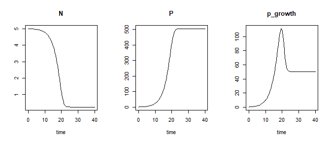

```r
library("deSolve")
library("rootSolve")

chemostat <- function(time, y, parms) {
  with(as.list(c(y, parms)), {
    p_growth <- r_pgrow * N / (k_n + N) * P

    dN_dt   <- - c_pn * p_growth + d * (N0 - N)
    dP_dt   <-          p_growth + d * (0 - P)
    list(c(dN_dt, dP_dt), p_growth = p_growth)
   })
}
parms <- c(
  r_pgrow = 0.5,   # phytoplankton growth parameter (1/d)
  k_n     = 1.0,   # half saturation constant, P (mmol/m3)
  c_pn    = 1/106, # stoichiometric conversion from phosphorus P to phyto C (P:C ratio)
  d       = 0.1,   # dilution rate 1/d
  N0      = 5      # phosphorus in inflow (mmol/m3)
)
test_parms <- parms
test_parms["d"] <- 0.1
times <- seq(from=0, to=40, length.out=100)  # simulation time (d)
y     <- c(N = 5, P = 1)                     # Nutrient (mmolP/m3) and Phytoplankton (mmolC/m3)
out <- ode(y, times, chemostat, test_parms)
plot(out, mfrow=c(1, 3))
```

## Solution: Scenarios with different patterns

Here we see some examples with different $d$. We see also that the plot function allows to show several scenarios simultanaeously:

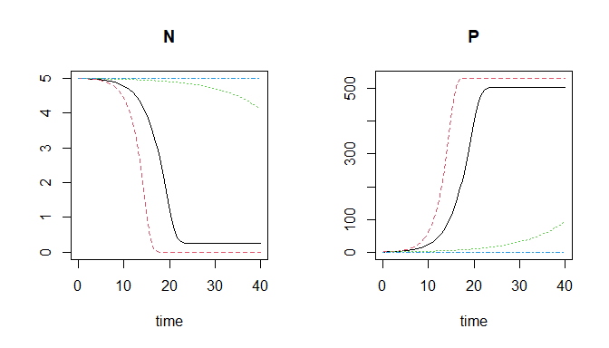

```r
times <- seq(from=0, to=40, length.out=100)  # simulation time (d)
y     <- c(N=5, P=1)
p1 <- p2 <- p3 <- parms
p1["d"] <- 0; p2["d"] <- 0.3; p3["d"] <- 0.5
out  <- ode(y, times, chemostat, parms)
out1 <- ode(y, times, chemostat, p1)
out2 <- ode(y, times, chemostat, p2)
out3 <- ode(y, times, chemostat, p3)

plot(out, out1, out2, out3, which=c("N", "P"))
```

## Steady State

In the sections above, we could see how the chemostat model approaches an equilibrium. As the model is very simple, the equilibrium can be calculated analytically by setting both state equations to zero and then solving the system of equations. The solution can then be plotted:

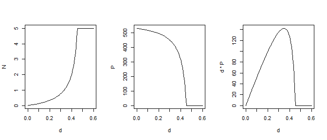

```r
d <- seq(0, 0.6, length.out = 100)
r <- 0.5;  kp <- 0.5; Y = 106; N0 = 5

N <- d * kp / (r - d)
N <- ifelse(d > (r * N0)/(kp + N0), N0, N)
P <- Y * (N0 - N)

par(mfrow=c(1, 3))
plot(d, N,     type="l")
plot(d, P,     type="l")
plot(d, d * P, type="l")
```

Here we see that with increasing $d$ the equilibrium phytoplankton concentration decreases and more nutrients are left over. The production, however (d*P) approaches an optimum at high dilution rates. If the dilution exceeds maximum growth, the chemostat dies out.

### Steady state solved numerically

To gain better understanding, we now want to estimate steady-state numerically and recreate the relationship with dilution rate. For this purpose, we may simulate the model for a long time until we see that the solution does not change anymore (equilibrium) and then take the last values.

But, as this is of course not very efficient, the equilibrium can also approximated numerically with package **rootSolve**.

We first create a data frame, where the first column is a sequence of dilution rates within a sensible range. The other two columns are then reserved for storing the results.

```r
state <- data.frame(
  d = seq(0.01, 0.5, length.out = 100),
  N = 0,
  P = 0
)

## example how to calculate a single equilibrium

parms["d"] <- state$d[5]
times <- c(0, Inf)
out <- runsteady(y, times, chemostat, parms)
out$y

## place a loop here to fill the data frame

# .............

## and then outcomment the plot
#par(mfrow = c(1, 3))
#plot(N     ~ d, data = state, type = "l")
#plot(P     ~ d, data = state, type = "l")
#plot(N * P ~ d, data = state, type = "l")
```

### Solution

```r
for (i in 1:nrow(state)) {
  parms["d"] <- state$d[i]
  times <- c(0, Inf)
  out <- runsteady(y, times, chemostat, parms)
  state[i, 2:3] <- out$y
}

par(mfrow = c(1, 3))
plot(N     ~ d, data = state, type = "l")
plot(P     ~ d, data = state, type = "l")
plot(d * P ~ d, data = state, type = "l")
```

[output not shown]

We use a `for`-loop here for simplicity, even if list-based approaches (e.g. `lapply`) may appear as more elegant for the intermediate and advanced **R** user.

## Outlook

The model shown here shows some essential properties of a flow-through system, used in biotechnology, wastewater treatment plants, or reservoirs and lakes. The following tutorials will build up on this and extend the idea further.

### References

Herbert, Denis, R Elsworth, and RC Telling. 1956. “The Continuous Culture of Bacteria; a Theoretical and Experimental Study.” *Microbiology* 14 (3): 601–22.

Novick, Aaron, and Leo Szilard. 1950. “Description of the Chemostat.” *Science* 112 (2920): 715–16.

R Core Team. 2018. *R: A Language and Environment for Statistical Computing*. Vienna, Austria: R Foundation for Statistical Computing. https://www.R-project.org/.

Soetaert, Karline. 2009. *rootSolve: Nonlinear Root Finding, Equilibrium and Steady-State Analysis of Ordinary Differential Equations. R Package 1.6*. https://cran.r-project.org/package=rootSolve.

Soetaert, Karline, Thomas Petzoldt, and R. Woodrow Setzer. 2010a. “Solving Differential Equations in R.” *The R Journal* 2 (2): 5–15. https://journal.r-project.org/archive/2010-2/RJournal_2010-2_Soetaert~et~al.pdf.

———. 2010b. “Solving Differential Equations in R: Package deSolve.” *Journal of Statistical Software* 33 (9): 1–25. https://doi.org/10.18637/jss.v033.i09.